# Data Analysis for WeRateDogs tweets

For this project, we gathered tweet data using different sources for user @WeRateDogs, just for fun! Just kidding, also to learn valuable lessons, such as, wrangling is always about iteration, and always remember to make a copy before cleaning your datasets.

To the important part! We cooked tidy and clean data and created a database of almost 2000 original WeRateDogs tweets with a lot of interesting information: the ratings, of course, timestamps, amount of likes and retweets, dog names, etcetera! And we're about to summarize some of the most interesting facts we found from this Twitter account (after countless hours of cleaning up, yay...), so let's check those out!

## "I Hate Mondays..."

Not according to the people behind WeRateDogs! We checked for activity in each day of the week of this popular dog-lover account, and we saw that Mondays were the most popular day to rate little puppers! In fact, when compared to weekends, which are on the opposite spectrum for activity frequency), we found that Mondays have a nearly 4% more tweets than Saturdays and Sundays, which doesn't sound like a lot, but it'd be almost 2 months worth of Mondays. it's the refreshing start of the week that gets Dog Raters more involved with the community!

## The most common names are... people's names?

Everyone gets creative when it comes to their animal babies, but I wanted to see if there were any repetitive names in the list, and I found that the most common names for doggos included such normal names as Charlie, Lucy and Cooper. Names like Enchilada or Rubio are on the opposite side of popularity, but hey, they're at least unique, right?

## Make way for everyone's favorites!

Since we had at hand a dataset with predictions of the dog breed for each photo (made with a cool neural network!... which we personally didn't make but it's cool either way), we wanted to see which were the most popular breeds according to this prediction, so we used our predictions, and by far the most popular (or maybe just easily predictable) dog breed was an all-time favorite, the Golden Retriever! What about the Pembroke, you Pembroke-lover must be wondering? Don't worry, the tiny-legged ones were the second most popular out of our predictions, followed closely by the Labrador Retriever in third place.

## Pupper or doggo?

A really classic debate among dog enthusiasts, some prefer older, some prefer puppies, well, we will find out now with the amount of likes! We collected likes for each tweet that contained the words "pupper", "doggo", "puppo" and "floofer" and we divided by sample size of each to get a ratio of likes for each dog stage, and the winner is... THE PUPPO! Surprisingly (but not so much if you've been on the internet for any period of time), people prefer a medium term when it comes to their dogs, and actually, puppers seem to be the least popular group among all four! Maybe our babies are not as cute as we thought they were?!

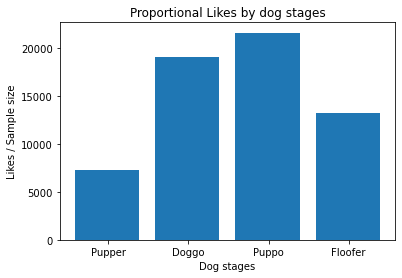